# Can Nonprofits Make High School Debate More Accessible? It’s Debatable.

An analysis of the Brooklyn Debate League’s impact on NYC tournament representation.

**Eshaal Ubaid**

Perspiring nerds in suits yelling at each other about nuclear arms deals… that’s the image that comes to mind when you think “debater.”

As a former debater, I can’t really defend myself there. Yet debate is more than just an ego boost for high schoolers. It is an avenue for social mobility, college access, and critical thinking skills that many adults never develop. For many students, it is also their only chance to travel and build lasting friendships.

That inherent value is part of why debate is so paywalled. Wealthier families pay for private coaching, travel, and tournament fees to get their kids ahead. In New York City, [the most segregated school district in the country](https://civilrightsproject.ucla.edu/press-releases/new-york-schools-most-segregated-in-the-nation/), most debate teams are come from private schools in wealthier areas. Most debaters know that the same few schools get to state championships and nationals over and over again.

The Brooklyn Debate League (BDL) is a nonprofit that has spent the last decade addressing this inequity, employing a partnership model that builds teams in schools that previously did not have them. The testimonials are compelling evidence of its success. However, I was wondering how much of a difference it actually makes on representation. **Does the BDL model actually improve school representation on the NYC circuit?**

To answer this, I compared the makeup of NYC schools, from the [NYS Education Department’s (NYSED) records](https://eservices.nysed.gov/sedreports/ReportList?id=1), to the most recent NYC debate circuit with and without BDL schools included. Representation here comes down to the distribution of the NYSED’s school classifications: public, private, parochial, and charter. Each uses a different funding structure, clueing us in on student socioeconomic status.

Here are the breakdowns:

*Tournament data provided by the BDL. Originally from Tabroom.com, a database of all high school debate tournaments.*

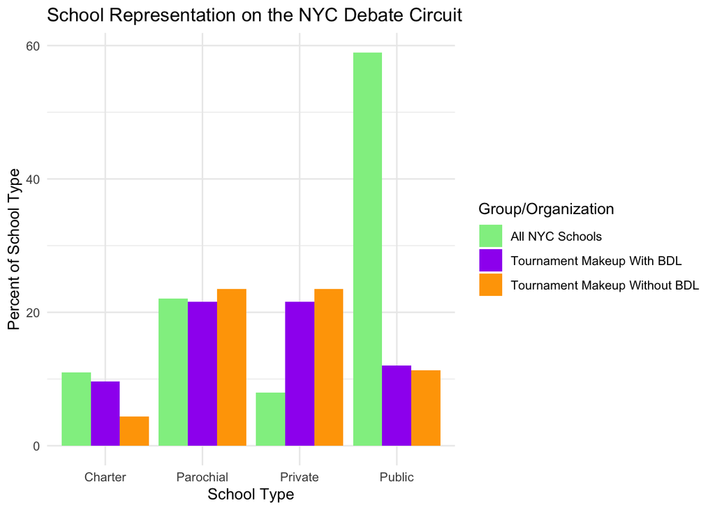

Evidently there’s a long way to go in order to make the debate circuit truly representative of NYC’s school makeup!

The BDL makes the biggest difference on charter school representation. It’s effectively brought that to the true makeup of about 10%, which is remarkable. This checks out because charter schools are tuition-free and often managed by nonprofits, making them more likely to be Title 1 schools (schools that receive funding to specifically serve low-income students).

However, the BDL barely improves public school representation or corrects for private school overrepresentation despite public schools comprising most of NYC’s school makeup. Perhaps this is because public schools have more bureaucratic red tape in place to form partnerships, or perhaps the charter school focus is intentional. The distribution of Title 1 schools the BDL serves confirms charter school dominance:

| Title 1 School Type | Percent of All Title 1 Schools |
| --- | --- |
| charter | 87.5 |
| public | 12.5 |

Still, this progress means students are now going to major tournaments that they wouldn’t have been able to attend otherwise. That’s some evidence that the model is working. It means that underrepresented voices are being increasingly heard in some of the fiercest rounds in the country.

The ultimate reward for establishing programs like this is giving underserved students opportunities to see their potential. Measuring the true impact of debate is hard, but I think one of the BDL’s debaters describes it best: “They saw how much I could grow and what I could become, even if I didn’t.”